# sRedList report - Thamnomys kempi

sRedList v1.2

Performed by victor.cazalis

29/04/2024

An assessment has been completed on the sRedList platform for the species *Thamnomys kempi* on the 29/04/2024. All outputs from this assessment are reported in the .csv and .shp files that were downloaded at the end of the assessment and they can be pushed on SIS through SIS Connect. This report is here to detail how these results were obtained (e.g., which parameters were used on the sRedList platform), to provide context around results (e.g., saving the different maps created on the platform), and help communication among assessors and with reviewers.

## Step 1: Distribution

For the whole process on the platform you used as polygon distribution the distribution that was published with the last Red List assessment. You then filtered the distribution, keeping only presence codes 1,2, origin codes 1,2, and seasonal codes 1,2.

You only kept the part of the distribution that is included in Congo, The Democratic Republic of the (National Red Listing option).

The distribution map used along the assessment was the following:

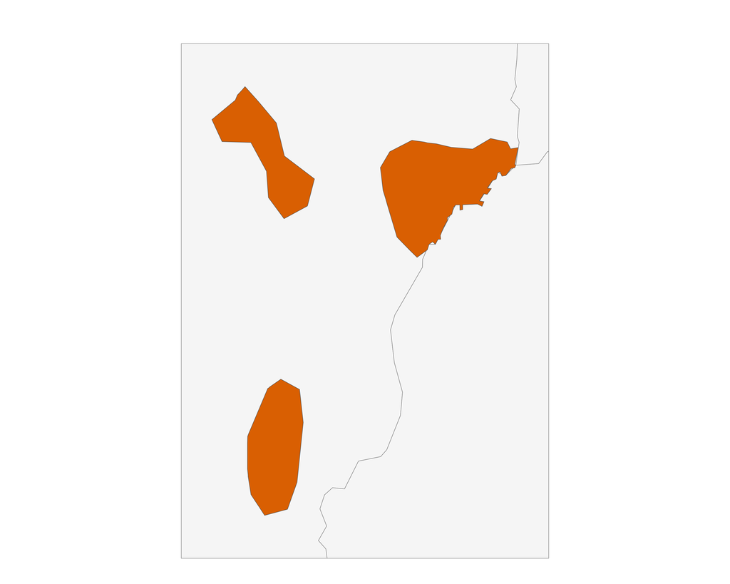

## Step 2: Countries of occurrence

This step was not performed on the platform.

## Step 3: Extent of occurrence

The extent of occurrence was calculated as the area of the minimum convex polygon around the distribution saved in Step 1. If you are confident that the distribution represents the true range of your species (including inferred presences), you can use this estimate in criterion B1.

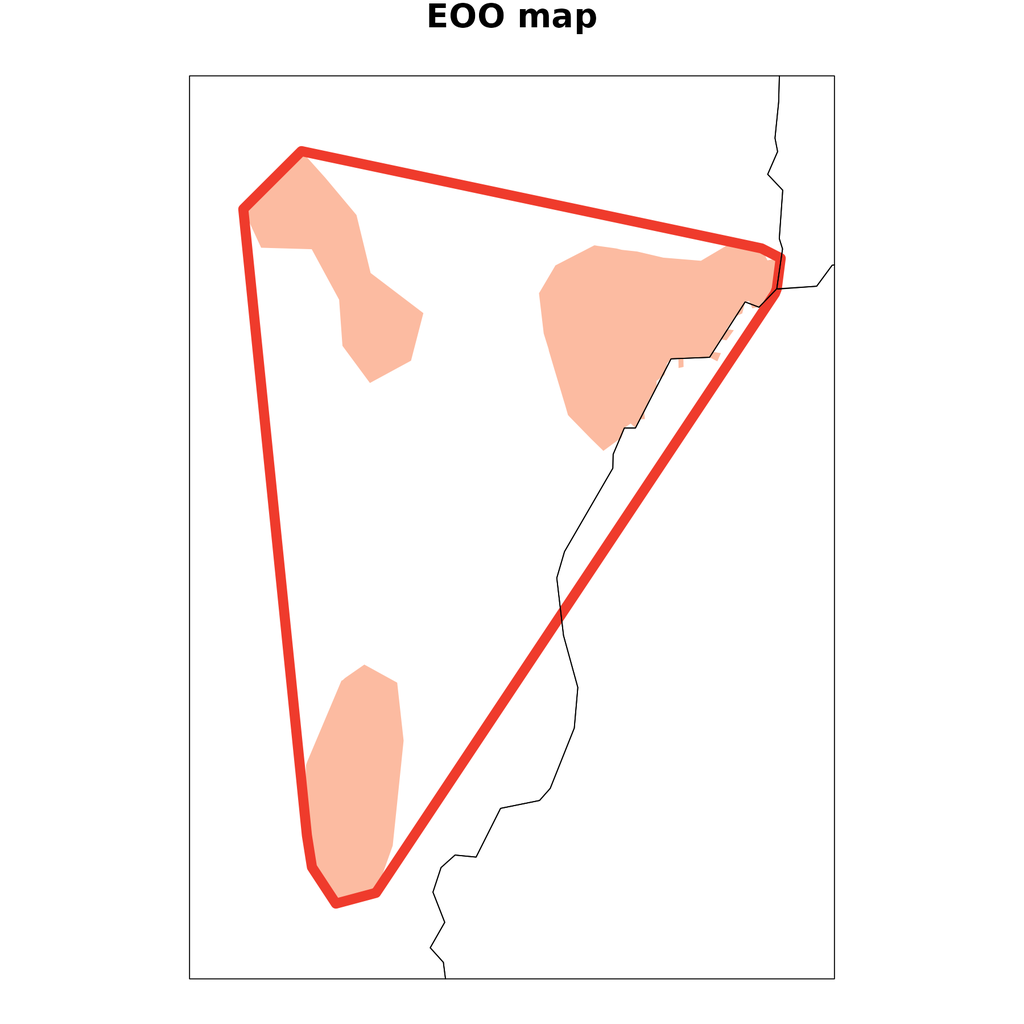

The extent of occurrence calculated by the platform was 10,354km<sup>2</sup>. The final extent of occurrence (present in the downloaded output) has a value of 10,354km2 and as justification :‘The EOO has been estimated as the Minimum Convex Polygon around the distribution on the sRedList platform.’.

## Step 4: Area of Habitat

### Habitat preferences

Habitat preferences were retrieved from a previous assessment with suitable habitats: 1.9

The habitat preferences used to map Area of Habitat were:

| Habitat lookup | Habitat name | Suitability |
| --- | --- | --- |
| 1.9 | Forest - Subtropical/Tropical Moist Montane | Suitable |

Note that the major importance and seasonality fields are left empty from the habitats.csv file, so you might want to complete that information in SIS later.

### Elevation preferences

Elevation preferences were suggested by the platform with a lower elevation limit of 1800m and an upper elevation limit of 3900m (extracted from the last Red List assessment). After a possibility to manually edit these values and add uncertainty in the estimates, the elevation preferences used to map Area of Habitat were 1800, 3900.

### Density

You used the density calculator, inputting a value of 172.82 for the density in total individuals within occupied habitat (a default value of 172.82 mature indificuals / km2 was suggested by the platform; check the sRedList documentation for more information); a value of 60-80 for the percentage of mature individuals; and a value of 40-60 for the percentage of suitable habitat that is occupied by the species. This resulted in a density in mature individuals within suitable habitat of 41.4768-82.9536 mature individuals / km2. The final density value you used to estimate population size was 41.4768-82.9536 mature individuals / km2 of suitable habitat.

### AOH calculation

The calculated Area of Habitat has a value of 1,048 km2.

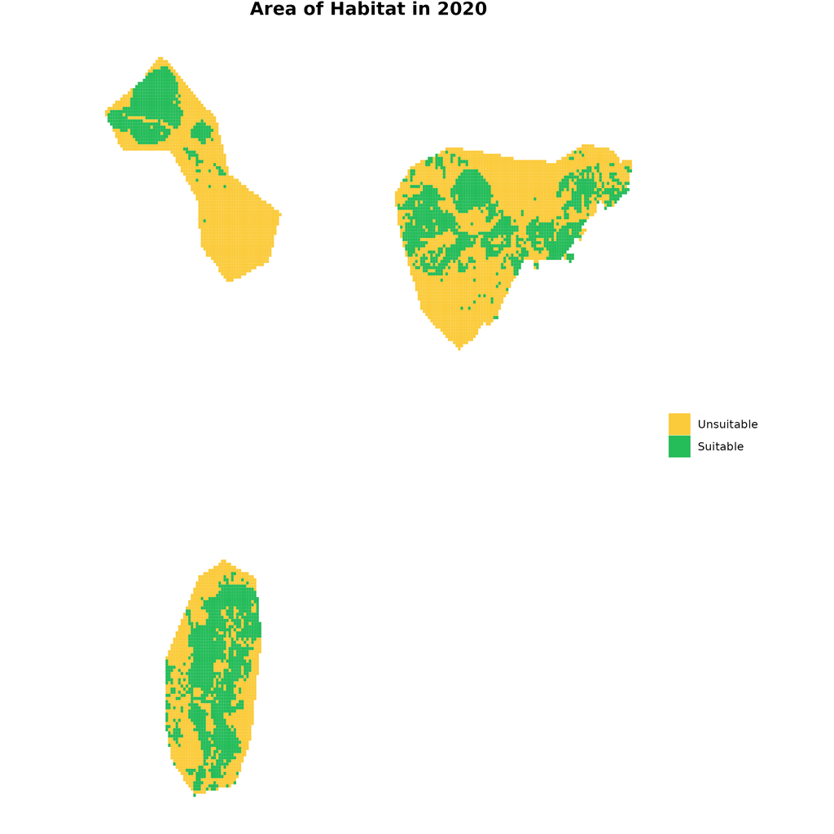

When rescaled at a 2x2km grid, this provides a value of 2,296 km2; this value can be used (if you trust the map) as an upper bound of area of occupancy if you consider likely that all the mapped suitable habitat is occupied by the species. If you know part of it is not occupied, you might want to reduce this estimate.

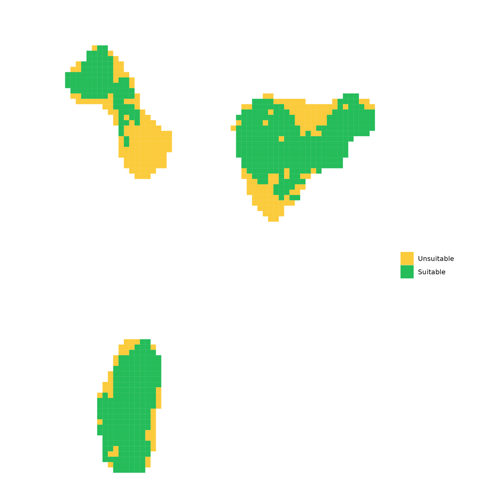

Based on the estimated Area of Habitat and the density value provided, we estimate the population size of your species is 43,468-86,935 mature individuals.

## Step 5: Trends in Area of Habitat

Trends in Area of Habitat were calculated with the same data and approach than Step 4. A generation length estimate was suggested by the platform with a value of 1.7 years. The generation length you provided is 1.7 years. The platform calculated trends between 2010 and 2020, which corresponds to the maximum between 10 years and 3 generations.

The platform found a reduction of 3% in Area of Habitat between 2010 and 2020 .

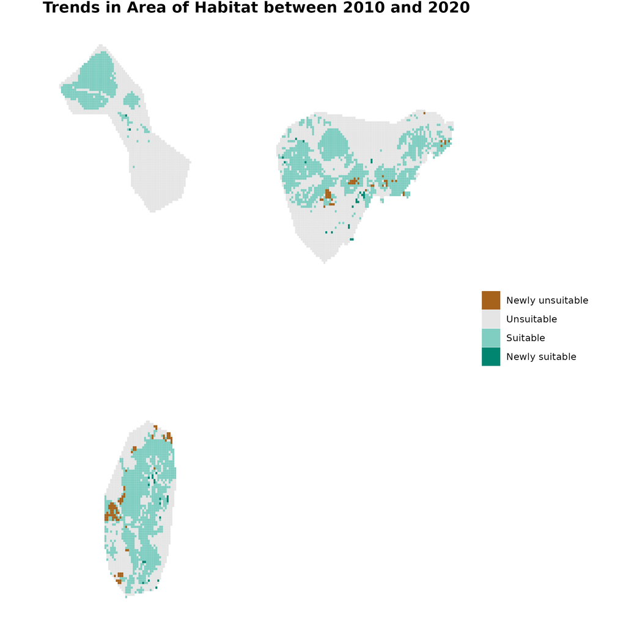

## Step 6: Fragmentation

Two parameters have to be provided to calculate fragmentation: the isolation distance (you provided the value 20 km) and the average density in mature individuals (you provided the value 41.4768-82.9536 inds/km2). You used the density calculator, inputting a value of 172.82 for the density in total individuals within occupied habitat (a default value of 172.82 mature indificuals / km2 was suggested by the platform; check the sRedList documentation for more information); a value of 60-80 for the percentage of mature individuals; and a value of 40-60 for the percentage of suitable habitat that is occupied by the species. This resulted in a density in mature individuals within suitable habitat of 41.4768-82.9536 mature individuals / km2.

The fragmentation resulting map was:

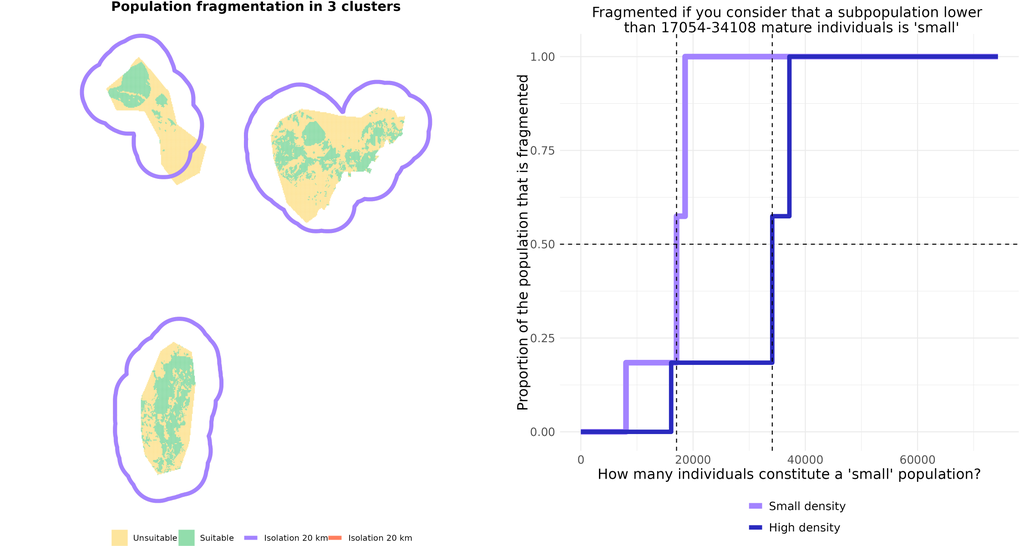

Assuming that you trust the map of Area of Habitat and that mapped clusters correspond to isolated subpopulations, this plot means that you can consider the population severely fragmented if you consider that a subpopulation lower than 17,054-34,108 mature individuals is small. You can check the sRedList documentation for interpretation.

If you trust that clusters represent isolated subpopulations, you can also use this analysis to inform subcriterion C2(a). We estimate that the largest subpopulation hosts 18,580-37,161 mature individuals (C2(ai)), representing 43% of the total population.

## Step 7: Trends in remote-sensing products

Trends in some remote-sensing products have been calculated. You can check the sRedList documentation to know more on the products we map.

You mapped and calculated trends in human population density using the Global Human Settlement dataset.

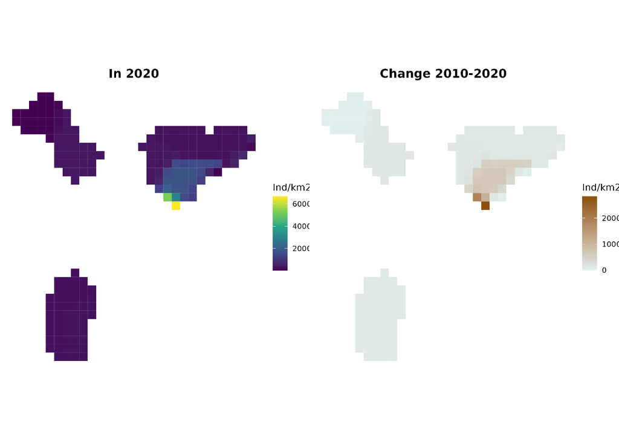

|  | Value |
| --- | --- |
| Current value | 268 (median Ind/km2) |
| Absolute trends | 82 (Ind/km2) |
| Relative trends | 30.8 % change in median |
| Time-window | 2010-2020 |

## Step 8: Summary and assign categories

After the summary step, these are the parameters that are included in the final output allfields.csv:

| Variable | Value |
| --- | --- |
| AOO.justification | The area of occupancy has been estimated on the sRedList Platform by rescaling the map of Area of Habitat to a 2x2km2 grid. This estimates corresponds to the upper bound of area of occupancy, as it as… |
| AOO.range | 2296 |
| EOO.justification | The EOO has been estimated as the Minimum Convex Polygon around the distribution on the sRedList platform. |
| EOO.range | 10354 |
| ElevationLower.limit | 1800 |
| ElevationUpper.limit | 3900 |
| GenerationLength.range | 1.7 |
| HabitatContinuingDecline.isDeclining | Yes |
| LocationsNumber.range | 6 |
| MatureIndividualsSubpopulation.value | 43 |
| MaxSubpopulationSize.range | 18580-37161 |
| NoThreats.noThreats | false |
| PopulationReductionPast.direction | Reduction |
| PopulationReductionPast.justification | This trend has been measured from the sRedList platform as the trend in Area of Habitat between 2010 and 2020 Trends in Area of Habitat are often very conservative and should be used only if no better… |
| PopulationReductionPast.range | 3 |
| PopulationSize.range | 43468-86935 |
| SevereFragmentation.isFragmented | No |
| ThreatsUnknown.value | false |
| internal_taxon_id | 21703 |
| internal_taxon_name | Thamnomys kempi |

These parameters lead to the following Red List criteria application (note though that this is just for visualisation and will not be pushed to SIS):

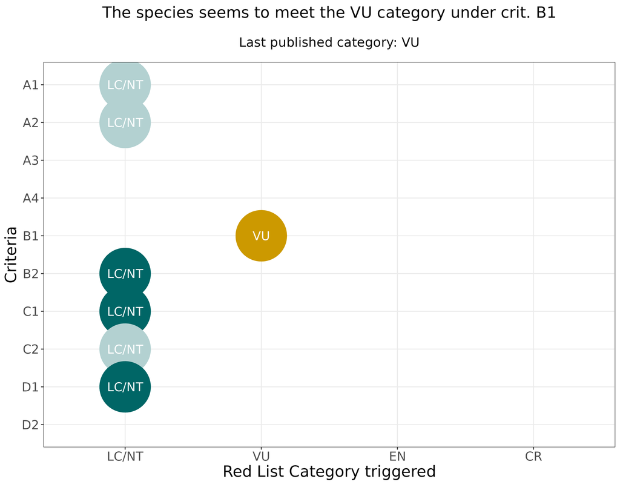

Thank you for using sRedList! You can now either go to SIS and paste the parameters calculated here that you find interesting, or use the ZIP file to push your assessment to SIS Connect.